# Classification

Author

Summer Tucker

Published

February 24, 2025

# **Abstract:**

This is a technical blog post of **both** an HTML file *and* [.qmd file](https://raw.githubusercontent.com/cd-public/D505/refs/heads/master/hws/src/classify.qmd) hosted on GitHub pages.

# 1. Setup

**Step Up Code:**

```r
sh <- suppressPackageStartupMessages
sh(library(tidyverse))
sh(library(caret))
sh(library(naivebayes))
sh(library(tidytext))
sh(library(pROC))
sh(library(SnowballC))
wine <- readRDS(gzcon(url("https://github.com/cd-public/D505/raw/master/dat/pinot.rds")))
```

# 2. Logistic Concepts

### Why do we call it Logistic Regression even though we are using the technique for classification?

###### *With a logistic regressoin model, we are calculating how a change in X determines whether Y will land in group A versus group B. This is different than the typical linear regression model where you’re calculating how a change in X influences the value of Y, and there are many different values of Y. However, with a logistic regrssion model, we are still iteratively calculating how close the data points are to a specific line (in this case an sort of S shaped curve) and determining how accurately that curve fits the data. So even though the formula is different in that it reports a different type of outcome (a binary outcome versus a continuous range of possible oucomes), the underlying approach of comparing the distance of each point to a line is still occuring.*

# 3. Modeling

### We train a logistic regression algorithm to classify a whether a wine comes from Marlborough using:

### 1. An 80-20 train-test split.

### 2. Three features engineered from the description

### 3. 5-fold cross validation.

```r
#Create a function that removes stop words, and any additional words we'd like to omit
desc_to_words <- function(df, omits) {
  df %>%
    unnest_tokens(word, description) %>%
    anti_join(stop_words) %>% # get rid of stop words
    filter(!(word %in% omits))
}

#Create a function that transforms the individual words into word stems
words_to_stems <- function(df) {
  df %>%
    dplyr::mutate(word = wordStem(word))
}

#Create a function that counts the number of times a word appears, and allows for filtering based on the number of times the word appears
filter_by_count <- function(df, j) {
  df %>%
    count(id, word) %>%
    group_by(id) %>% mutate(exists = (n>0)) %>% ungroup %>%
    group_by(word) %>%
   dplyr:: mutate(total = sum(n)) %>%
    filter(total > j)
}

#Create a function that turns individual words into columns, removes NAs, and removes id column
pivoter <- function(words, df) {
  words %>%
    pivot_wider(id_cols = id, names_from = word, values_from = exists, values_fill = list(exists=0)) %>%
    right_join(select(df,id,province)) %>%
    drop_na() %>%
    select(-id)
}

#Create another function that combines the above functions into one
wine_words <- function(df, j, stem) {

  words <- desc_to_words(df, c("wine","pinot","vineyard","drink"))

  if (stem) {
    words <- words_to_stems(words)
  }

  words <- filter_by_count(words, j)

  pivoter(words, df)
}
```

```r
#Apply wine_words to wine dataset and pare down the columns enough so there are only 3 features left

wineM <- wine_words(wine, 1500, T) %>%
          dplyr::mutate(marlborough = as.factor(province == "Marlborough")) %>%
          dplyr::select(-province,-raspberri,-spice,-flavor,-fruit,-ripe,-tannin,-palat,-acid,-black,-light,-red)
#Partion the data into an 80/20 split
wine_index <- createDataPartition(wineM$marlborough, p = 0.80, list = FALSE)
train <- wineM[wine_index, ]
test <- wineM[-wine_index, ]

#Run a logistic regression algorithm, using 5 fold cross validation.

fit <- train(marlborough~ .,
             data = train,
             method = "glm",
             family = "binomial",
             trControl = trainControl(method = "cv", number=5))

fit
```

```
Generalized Linear Model

6629 samples
   3 predictor
   2 classes: 'FALSE', 'TRUE'

No pre-processing
Resampling: Cross-Validated (5 fold)
Summary of sample sizes: 5304, 5303, 5304, 5302, 5303
Resampling results:

  Accuracy   Kappa
  0.9726959  0
```

##### *The Kappa value is zero.*

# 4. Binary vs Other Classification

### What is the difference between determining some form of classification through logistic regression versus methods like $K$-NN and Naive Bayes which performed classifications?

##### *Logistic regression is a method for classifying data points into one of two possible groups. For example, you could use logistic regression to predict whether a wine is red or not red, or whether Reviewer A rates a wine as excellent, or not excellent. Logistic regression accomplishes this by calculating the probability of an event, but is only predicting the probability of an event with a binary outcome. In comparision, KNN and Naive Bayes take different approaches to classification. KNN looks at a target data point, finds a specific number of it’s nearest neighboring data points, and classifies the target point based on whichever group makes up a majority of the neighboring points. Similar to logistic regression, Naive Bayes also uses probability calculations to make a prediction. But, with Naive Bayes you’re calculating the probability that a specific outcome occurs, based on value of the independent variable(s). For example, you could use Naive Bayes to find the probability a wine is from California, given that a wine has a cherry flavor. You could use all of these options to predict whether a data point falls into a specific class, but the method for doing so is different in each.*

*Source: https://www.geeksforgeeks.org/naive-bayes-vs-logistic-regression-in-machine-learning/*

# 5. ROC Curves

### We can display an ROC for the model to explain your model’s quality.

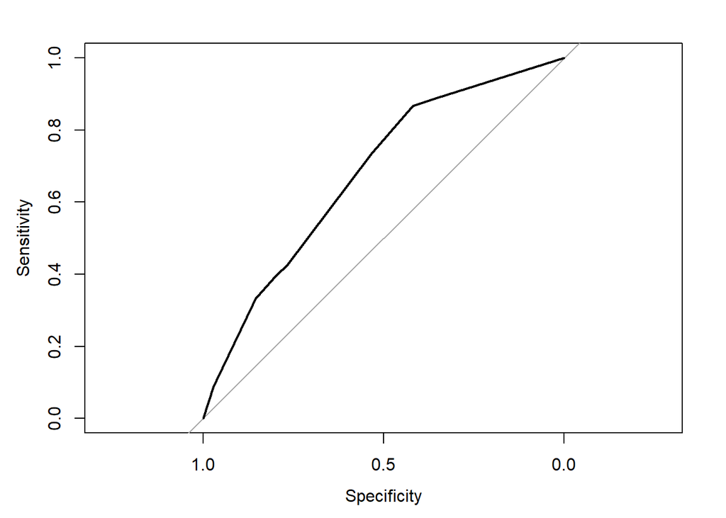

```r
prob <- predict(fit, newdata = test, type = "prob")[,2]
myRoc <- roc(test$marlborough, prob)
plot(myRoc)
```

```r
auc(myRoc)
```

```
Area under the curve: 0.6778
```